# Python to R Cheat Sheet

## **Calling Python in R**

R allows you to call Python and it’s libraries/functions using the reticulate library. That’s what I’ll be using to have my Python and R code in one document.

**My Method:**

*(Assuming R and RStudio are downloaded)*

1. Install Conda - https://www.anaconda.com/
2. Open RStudio and run the following code helpful video - https://www.youtube.com/watch?v=qATvD6kQ47s

```r
#install reticulate package
install.packages('reticulate')

#load package
library(reticulate)

#check configuration of reticulate
reticulate::py_config()

#if multiple versions of python are installed, can use this to select one of choice
use_python(path, required = TRUE)

#load python shell
repl_python()
```

Will switch the console to a Python interpreter. “exit” will revert back to R code.

In Rmarkdown, use “```{python}” at the beginning of chunk to use Python for that section.

## **Loading Python Packages**

May need to install the package to call in R first with this function

```r
py_install("pandas")
```

Then import libraries like you would from Python

```python
import pandas
```

## **Reading .csv and .xlsx Files**

### In R

```r
library(readr)
library(readxl)

df <- read.csv("C:\\Users\\pmcgee\\OneDrive - nassaucandy.com\\Documents\\Mastering_Shiny\\Data\\iris.csv")
read_excel("C:\\Users\\pmcgee\\OneDrive - nassaucandy.com\\Documents\\Mastering_Shiny\\Data\\iris.xlsx")
```

### In Python

```python
import pandas as pd

df = pd.read_csv("C:\\Users\\pmcgee\\OneDrive - nassaucandy.com\\Documents\\Mastering_Shiny\\Data\\iris.csv")
pd.read_excel("C:\\Users\\pmcgee\\OneDrive - nassaucandy.com\\Documents\\Mastering_Shiny\\Data\\iris.xlsx")
```

## **Inspecting a Data Frame**

### In R

I like to pair my functions with the ‘pipe’ %>% operator from the magrittr package. (Ctrl + Shift + M).

You Definitely don’t need to do this for a simple call for one function but it makes it easier when we want to chain multiple functions together to be in the habit of using the pipe.

```r
# view first n rows
df %>% head()

#view last n rows
df %>% tail()

#number of rows
df %>% nrow()

#number of columns
df %>% ncol()

#rows and columns
df %>% dim()

#summary stats of df by column
df %>% summary()

# view all columns with their column class and some data
df %>% glimpse()
# or
df %>%  str()
```

### In Python

```python
# view first n rows
df.head()

#view last n rows
df.tail()

#number of rows
df.shape[0]

#number of columns
df.shape[1]

#rows and columns
df.shape

#summary stats of df by column
df.info()

# view all columns with their column class and some data
df.describe()
```

# **Data Wrangling**

## **Passing Objects between Python and R in reticulate**

Let’s say I have a data frame that I loaded into my RStudio IDE via R.

```r
df <- iris

df %>% head()
```

| Sepal_Length | Sepal_Width | Petal_Length | Petal_Width | Species |
| --- | --- | --- | --- | --- |
| 5.1 | 3.5 | 1.4 | 0.2 | setosa |
| 4.9 | 3.0 | 1.4 | 0.2 | setosa |
| 4.7 | 3.2 | 1.3 | 0.2 | setosa |
| 4.6 | 3.1 | 1.5 | 0.2 | setosa |
| 5.0 | 3.6 | 1.4 | 0.2 | setosa |
| 5.4 | 3.9 | 1.7 | 0.4 | setosa |

If I wanted to pass this object (in this case a dataframe) to Python I can using reticulate.

R Objects are called in python using the syntax “r.’object_name’”

```python
py_df = r.df

py_df.head()
```

```
##    Sepal_Length  Sepal_Width  Petal_Length  Petal_Width Species
## 0           5.1          3.5           1.4          0.2  setosa
## 1           4.9          3.0           1.4          0.2  setosa
## 2           4.7          3.2           1.3          0.2  setosa
## 3           4.6          3.1           1.5          0.2  setosa
## 4           5.0          3.6           1.4          0.2  setosa
```

If I wanted to do the opposite and pass a Python object to R, it gets called with the syntax “py$‘object_name’”

```r
df <- py$py_df

df %>% head()
```

| Sepal_Length | Sepal_Width | Petal_Length | Petal_Width | Species |
| --- | --- | --- | --- | --- |
| 5.1 | 3.5 | 1.4 | 0.2 | setosa |
| 4.9 | 3.0 | 1.4 | 0.2 | setosa |
| 4.7 | 3.2 | 1.3 | 0.2 | setosa |
| 4.6 | 3.1 | 1.5 | 0.2 | setosa |
| 5.0 | 3.6 | 1.4 | 0.2 | setosa |
| 5.4 | 3.9 | 1.7 | 0.4 | setosa |

## **Filtering**

### In R

I’ll be pairing solutions in dplyr with their data.table alternatives when applicable, which is faster for very large data.

```r
library(tidyverse)
library(data.table)

#filter with data.table need to convert to a data.table object first
df <- data.table(df)
df[Species == "setosa"]

#1. basic filtering
filter(df, Species == "setosa")
df %>% filter(Species == "setosa")


#2. filter multiple columns
df %>% filter(Species == "virginica" & Sepal_Width >= 3.5)

#filter multiple columns with data.table
df[Species == "virginica" & Sepal_Width >= 3.5]


#3. Intermediate filtering

#3a. using %in%
x <- c("setosa", "virginica")
df %>% filter(Species %in% x)

#data.table using %in% and %chin% (faster than %in% for characters)
x <- c("setosa", "virginica")
df[Species %in% x]
df[as.character(Species) %chin% x]

#3b. using %like%
df %>% filter(Species %like% "set")

# data.table using %like%
df[Species %like% "set"]

#3c. using %between%
df %>% filter(Petal_Length %between% c(1,2))
```

### In Python

```python
import numpy as np
import pandas as pd

#1. basic filtering
df[df['Species'] == "setosa"]
df[df.Species == "setosa"]

# using query method
df.query("Species == 'setosa'")


#2. filter multiple columns
df[(df['Species'] == "virginica") & (df["Speal_Width"] >= 3.5)]

#query method for multiple columns
df.query("Species == 'setosa' and `Speal_Width` >= 3.5")

#3. Intermediate filtering

#3a. using .isin()
df['Species'].isin(['setosa'])

#3b. Partial string match
df['Species'].str.contains('set', case = False, na = False)
```

## **Selecting**

### In R

```r
#1. Selecting and dropping columns
select(df, Species, Sepal_Length)
select(df, -Petal_Length)

# data.table
df[,c("Species", "Sepal_Length")]
df[, -("Petal_Length")]

#2. selecting row by position
df[1:5,]

#3. Selecting rows based on condition
df[df$Species == 'setosa',]
```

### In Python

```python
#1. Selecting and dropping columns
df[["Species", "Sepal_Length"]]
df.drop("Petal_Length", 1)

#2. selecting row by position
df.iloc[0:5]
df.loc[0:4]

#3. Selecting rows based on condition
df.loc[df.Species == "setosa"]
```

## **Arrange**

### In R

```r
df %>% arrange(Species)
df %>% arrange(desc(Species))

#data.table
setorder(df, cols = "Species")
setorder(df, cols = - "Species")
```

### In Python

```python
df.sort_values("Species")
df.sort_values("Species", ascending = False)
```

## **Grouping**

### In R

```r
df %>% group_by(Species)
df %>% group_by(Species, Sepal_Length)
df %>% ungroup()
```

### In Python

```python
df.groupby("Species")
df.groupby(["Species", "Sepal_Length"])
```

## **Group by and Aggregating/Summarizing**

### In R

Useful post - https://stackoverflow.com/questions/38935541/what-is-the-pandas-equivalent-of-dplyr-summarize-aggregate-by-multiple-functions

```r
# 1. Basic Group by and aggregate
df %>%
  group_by(Species) %>%
  summarize(mean_sepal_length = mean(Sepal_Length))

# 2. grouping by one column and performing multiple aggregations on same column
df %>%
  group_by(Species) %>%
  summarize(mean_sepal_length = mean(Sepal_Length),
            max_sepal_length = max(Sepal_Length),
            min_sepal_length = min(Sepal_Length))

# 3. grouping by one column and performing aggregations on multiple columns
df %>%
  group_by(Species) %>%
  summarize(mean_sepal_length = mean(Sepal_Length),
            max_petal_width = max(Petal_Width))

# 3a. Using across (apply same function easily to multiple columns)
df %>%
  group_by(Species) %>%
  summarize(
    across(c(Speal_Width, Petal_Width),
                  .fns =  list(mean = mean, max = max, min = min), na.rm = TRUE, .names = "{col}_{fn}"))

# 3b. Using across apply multiple functions to multiple columns
df %>%
  group_by(Species) %>%
  summarize(
    across(everything(),
                  .fns =  list(mean = mean, max = max, min = min), na.rm = TRUE, .names = "{col}_{fn}"))

#data.table method

# 1. Basic Group by and aggregate
df[,. (mean_sepal_length = mean(Sepal_Length)), by = Species]

# 2. grouping by one column and performing multiple aggregations on same column
df[,. (mean_sepal_length = mean(Sepal_Length), max_sepal_width = max(Speal_Width), min_sepal_width = min(Speal_Width)), by = Species]

# 3. grouping by one column and performing aggregations on multiple columns
df[,. (mean_sepal_length = mean(Sepal_Length), max_petal_width = max(Petal_Width)), by = Species]
```

### In Python

Useful post - https://stackoverflow.com/questions/38935541/what-is-the-pandas-equivalent-of-dplyr-summarize-aggregate-by-multiple-functions

```python
# 1. Basic Group by and aggregate
df.groupby("Species").agg({'Sepal_Length' : 'mean'})

# 1a. rename calculated column and remove column index
df.groupby('Species')['Sepal_Length'].agg(['mean']).rename(columns={'mean': 'mean_sepal_length'}).reset_index()


# 2. grouping by one column and performing multiple aggregations on same column
df.groupby("Species").agg({'Sepal_Length' : ['mean', 'min', 'max']})


# 3. grouping by one column and performing aggregations on multiple columns
#can, but dont need to reset index
df.groupby(["Species"]).agg({"Sepal_Length" : ["mean"], "Petal_Width" : ["max"]})

# 3a. can save as variable and then index the df
df2 = df.groupby(["Species"]).agg({"Sepal_Length" : ["mean"], "Sepal_Length" : ["max"]})
df2["Sepal_Length"].reset_index()

# 3b. group by and Apply multiple functions to multiple columns
df.groupby('Species').agg({'Sepal_Length':['sum','mean','std'],'Petal_Width':['sum','mean','std'],'Petal_Length':['sum','mean','std']})

# 3c. Group by and apply function to all columns
df.groupby('Species').agg(['mean','min','max']).reset_index()
```

## **Chained Operations**

### In R

```r
#group by and filter
df %>% group_by(Species) %>% filter(sum(Petal_Width) > 100)
```

### In Python

```python
#group by and filter
df.groupby('Species').filter(lambda x: sum(x['Petal_Width']) > 100)
```

## **Missing Values**

### In R

```r
#number of missing values in each column
map(df, ~sum(is.na(.)))

#replacing missing values
df %>% mutate(Sepal_Length = replace_na(Sepal_Length, 0))

df$Sepal_Length[is.na(df$Sepal_Length)] <-0
```

### In Python

```python
#number of missing values in each column
df.isna().sum()

#replacing missing values
```

```
## Sepal_Length    0
## Sepal_Width     0
## Petal_Length    0
## Petal_Width     0
## Species         0
## dtype: int64
```

```python
df['Sepal_Length'] = df['Sepal_Length'].fillna(0)
```

## **Creating new Columns**

### In R

```r
# using mutate
df %>%
  mutate(Petal_L_W = Petal_Length + Petal_Width)
```

### In Python

```python
#using assign
df.assign(Petal_W_L =  df['Petal_Length'] + df['Petal_Width'])
```

## **Joining/Sorting**

### In R

```r
#split df by column number to join back together

df1 <- df[ ,c(1:2,5)]
df2 <- df[,c(3:5)]
```

### In Python

```python
#split df by column number to join back together

#remember, Python is 0 indexed
df1 = df.iloc[:,[0,1,4]]

df2 = df.iloc[:,2:5] # Select between indexes 1 and 4 (2,3,4)
df2 = df.iloc[:,2:] # Select From 3rd to end
df2 = df.iloc[:,2:5] # select From 3rd to 5th
```

## **Visualizations**

### In R

### In Python

#### **Plotting with matplotlib**

```python
# PREPARING DATA TO PLOT

import numpy as np
import matplotlib.pyplot as plt
import pandas as pd

#group by and agg to get stats to plot
df3 = df.groupby('Species')['Sepal_Length'].agg(['mean']).rename(columns={'mean': 'mean_sepal_length'}).reset_index()

#sample dataframe with a date column
months =  pd.date_range('2021-01-01','2022-01-01' , freq='1M')-pd.offsets.MonthBegin(1)
apples_picked = [12,22,45,50,75,80,68,82,90,77,76,54]

time_df = pd.DataFrame()
time_df['months'] = months
time_df['apples_picked'] = apples_picked
```

```python
#histogram
df.hist('Sepal_Width')
```

```
## array([[<AxesSubplot: title={'center': 'Sepal_Width'}>]], dtype=object)
```

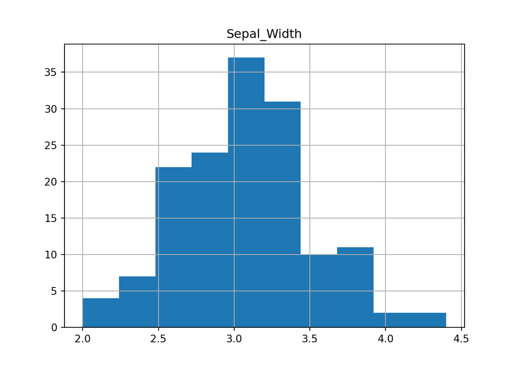

```python
plt.show()
```

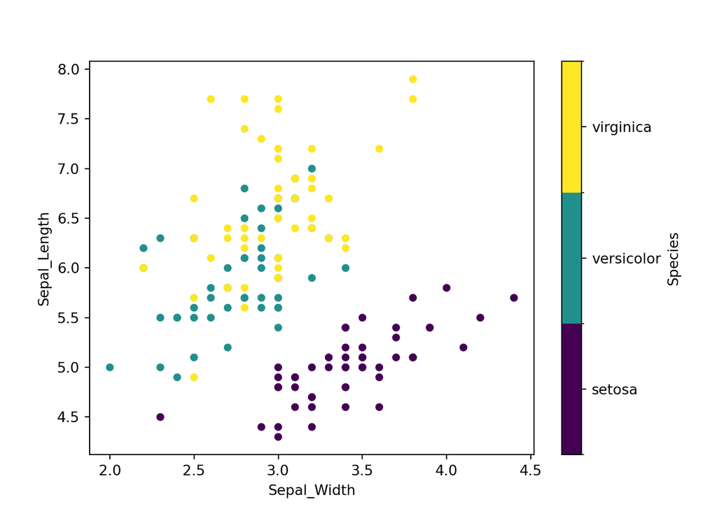

```python
#scatterplot
df.plot.scatter(x = 'Sepal_Width', y = 'Sepal_Length', c = 'Species', cmap = "viridis")
plt.show()
```

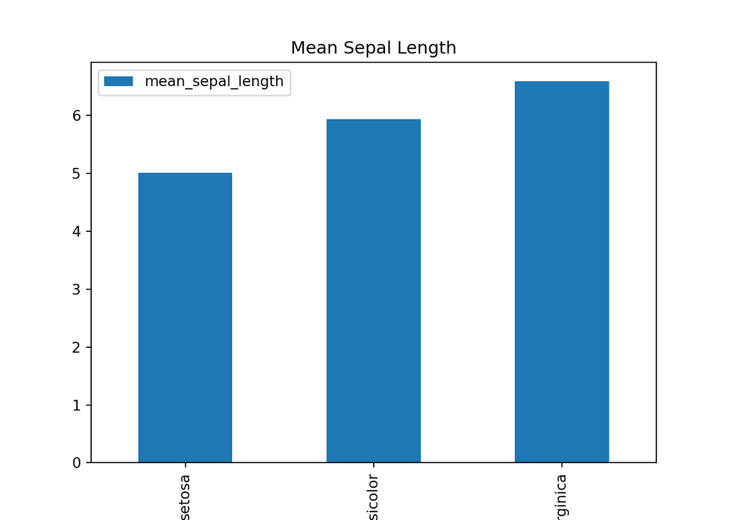

```python
#basic bar plot
df3.plot(kind = "bar", x = "Species", title='Mean Sepal Length')
plt.show()
```

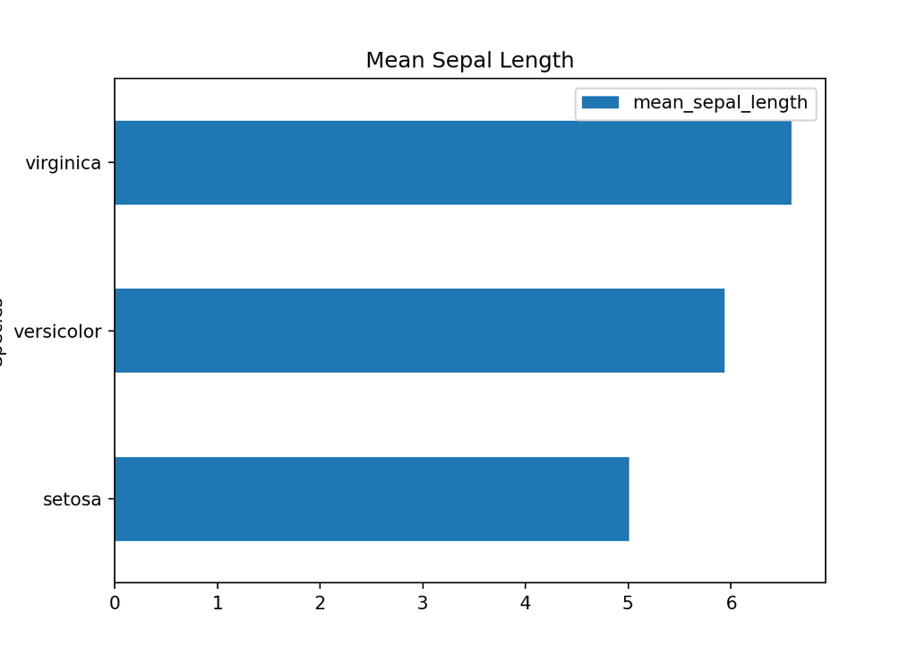

```python
#basic horizontal bar plot
df3.plot(kind = "barh", x = "Species", title='Mean Sepal Length')
plt.show()
```

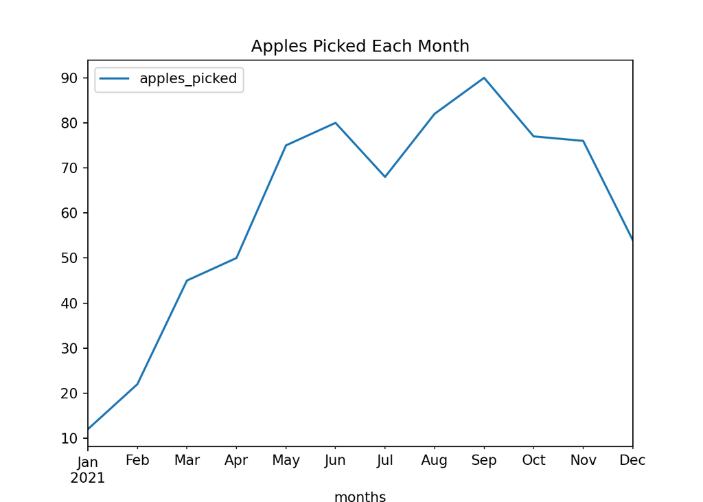

```python
#basic line plot
time_df.plot(x = 'months', y = 'apples_picked', kind = 'line', title = "Apples Picked Each Month")
plt.show()
```

#### **Plotting with Seaborn**

```python
import seaborn as sns
import matplotlib.pyplot as plt
```

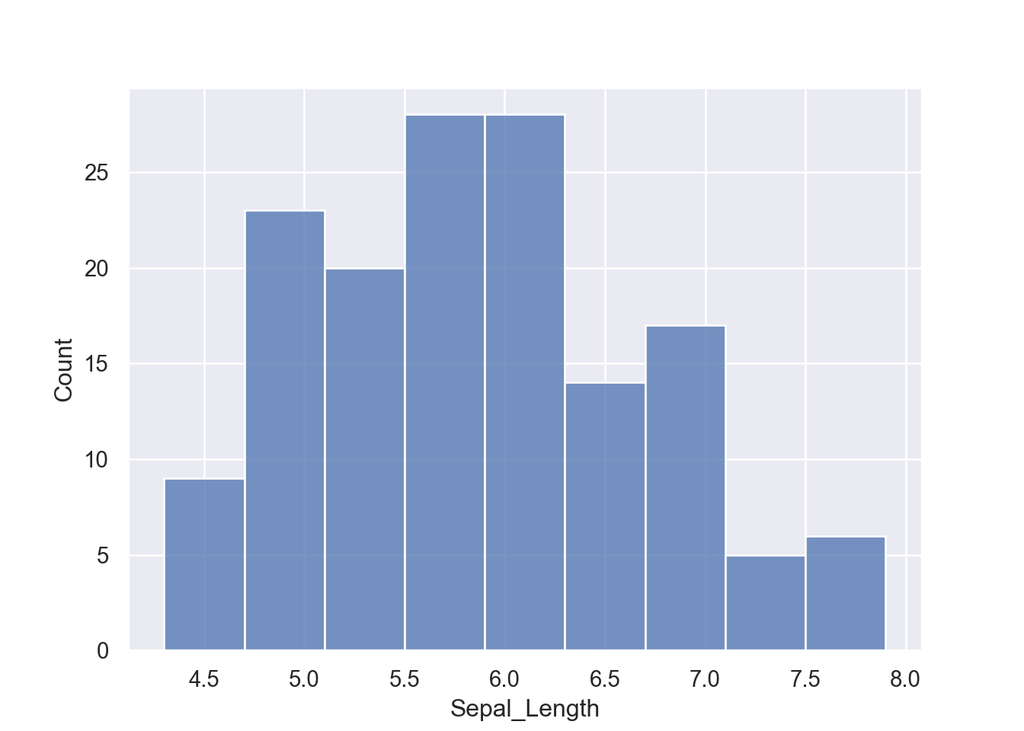

```python
#histogram
plt.figure()
sns.set(style="darkgrid")
sns.histplot(data = df, x = "Sepal_Length")
plt.show()
```

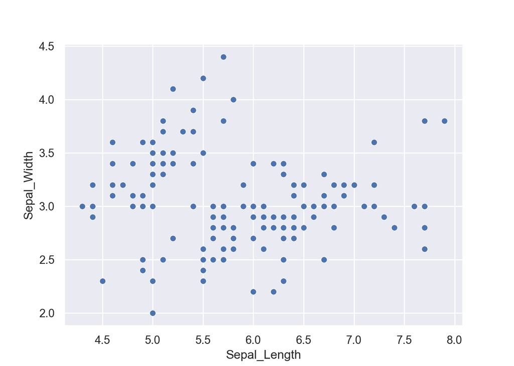

```python
#scatterplot
plt.figure()
sns.scatterplot(data = df, x = "Sepal_Length", y = "Sepal_Width")
plt.show()
```

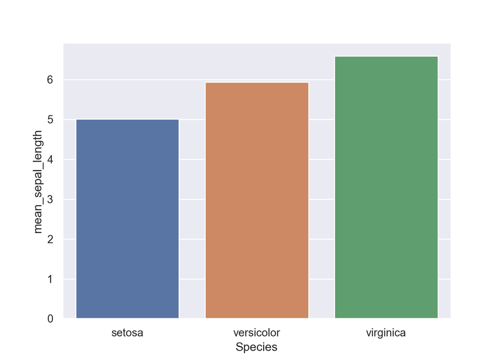

```python
#basic bar plot
plt.figure()
sns.barplot(x = 'Species', y = 'mean_sepal_length', data = df3)
plt.show()
```

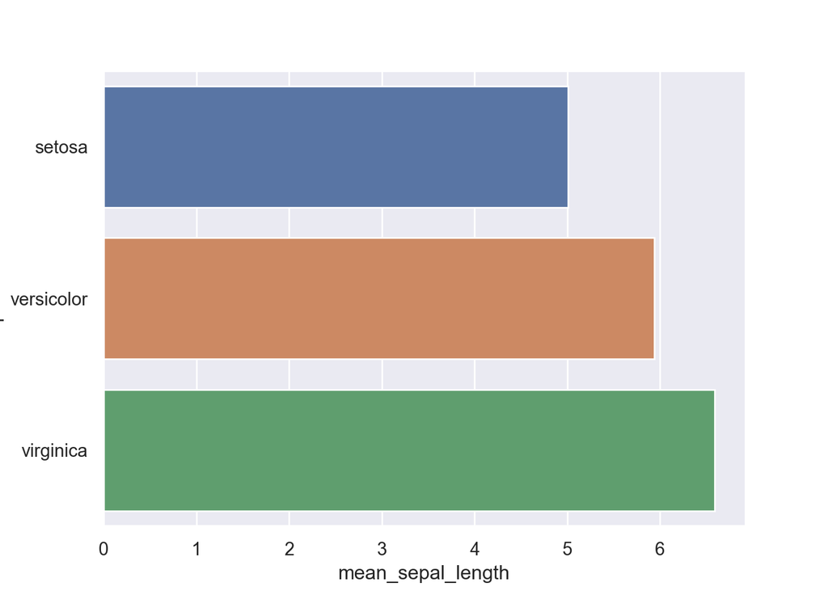

```python
#basic horizontal bar plot
plt.figure()
sns.barplot(x = 'mean_sepal_length', y = 'Species', data = df3, orient = "h")
plt.show()
```

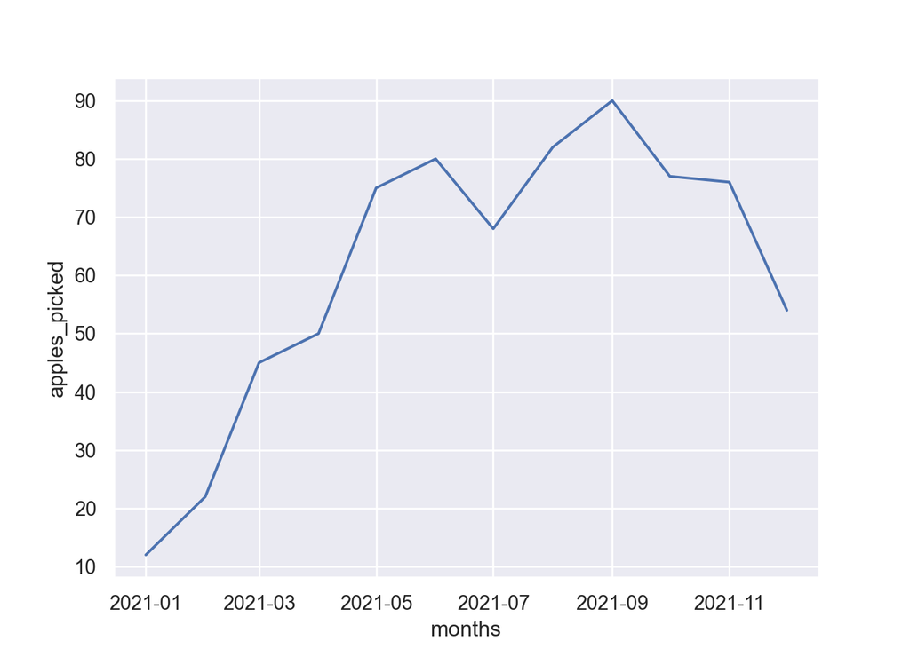

```python
#basic line plot
plt.figure()
sns.lineplot(x = 'months', y = "apples_picked", data = time_df)
plt.show()
```

## **Using SQL (SSMS)**

### In R

```r
library(DBI)
library(odbc)

# database connection ####
con <- DBI::dbConnect(odbc::odbc(),
                      Driver = "ODBC Driver 17 for SQL Server",
                      Server = "",
                      UID = "",
                      PWD = ''
                      )

# Query
data = dbGetQuery(con, "SELECT * FROM Database..Table WHERE CallDate >= '2022-01-01' ORDER BY 1 DESC", .con = con))
```

### In Python

```python
import pyodbc
from sqlalchemy.engine import URL
from sqlalchemy import create_engine


connection_string = 'DRIVER={ODBC Driver 17 for SQL Server};''SERVER=;''UID=;''PWD=;'
connection_url = URL.create("mssql+pyodbc", query={"odbc_connect": connection_string})

engine = create_engine(connection_url)

data = pd.read_sql("SELECT TOP(100) * FROM Database..Table", engine)
```

## **Sending Emails**

### In R

### In Python